# Diagnóstico e consertos para modelos lineares

# Problemas possíveis

1. Non-linearity of the response-predictor relationships.
2. Correlation of error terms.
3. Non-constant variance of error terms.
4. Outliers.
5. High-leverage points.
6. Collinearity.

## Não linearidade na relação entre preditores e variável de resposta

### Caso 1

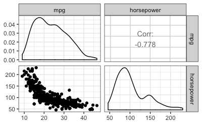

```r
auto = select(Auto, mpg, horsepower)
ggpairs(auto)
```

```r
automodel = lm(mpg ~ horsepower, data = auto)
tidy(automodel, conf.int = TRUE)
```

| term | estimate | std.error | statistic | p.value | conf.low | conf.high |
| --- | --- | --- | --- | --- | --- | --- |
| (Intercept) | 39.9358610 | 0.717498656 | 55.65984 | 1.220362e-187 | 38.525212 | 41.3465103 |
| horsepower | -0.1578447 | 0.006445501 | -24.48914 | 7.031989e-81 | -0.170517 | -0.1451725 |

```r
glance(automodel)
```

| r.squared | adj.r.squared | sigma | statistic | p.value | df | logLik | AIC | BIC | deviance | df.residual |
| --- | --- | --- | --- | --- | --- | --- | --- | --- | --- | --- |
| 0.6059483 | 0.6049379 | 4.905757 | 599.7177 | 7.031989e-81 | 2 | -1178.662 | 2363.324 | 2375.237 | 9385.916 | 390 |

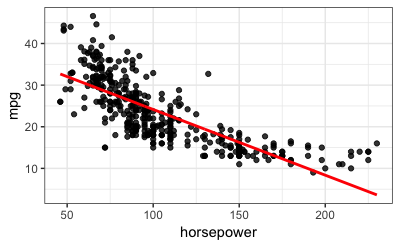

```r
grid = auto %>%
  add_predictions(model = automodel)
ggplot(grid, aes(horsepower)) +
  geom_point(aes(y = mpg), alpha = .8) +
  geom_line(aes(y = pred), colour = "red", size = 1)
```

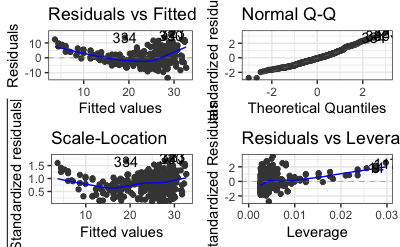

```r
autoplot(automodel)
```

Uma solução possível é tentar polinômios de grau mais alto, que têm curva.

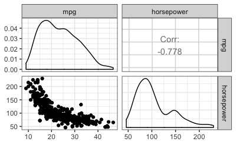

```r
ggpairs(auto)
```

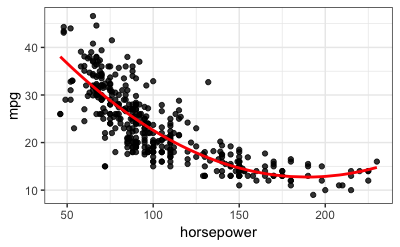

```r
automodel = lm(mpg ~ horsepower + I(horsepower^2), data = auto)
grid = auto %>%
  mutate(horsepower2 = horsepower^2) %>%
  add_predictions(model = automodel)
ggplot(grid, aes(horsepower)) +
  geom_point(aes(y = mpg), alpha = .8) +
  geom_line(aes(y = pred), colour = "red", size = 1)
```

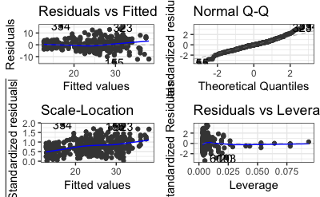

```r
autoplot(automodel)
```

```r
tidy(automodel)
```

| term | estimate | std.error | statistic | p.value |
| --- | --- | --- | --- | --- |
| (Intercept) | 56.900099702 | 1.8004268063 | 31.60367 | 1.740911e-109 |
| horsepower | -0.466189630 | 0.0311246171 | -14.97816 | 2.289429e-40 |
| I(horsepower^2) | 0.001230536 | 0.0001220759 | 10.08009 | 2.196340e-21 |

```r
glance(automodel)
```

| r.squared | adj.r.squared | sigma | statistic | p.value | df | logLik | AIC | BIC | deviance | df.residual |
| --- | --- | --- | --- | --- | --- | --- | --- | --- | --- | --- |
| 0.687559 | 0.6859527 | 4.373921 | 428.0176 | 5.399723e-99 | 3 | -1133.177 | 2274.354 | 2290.239 | 7442.029 | 389 |

### Caso 2

(Na minha experiência, esse é mais comum)

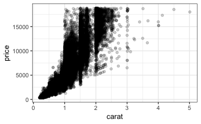

```r
ggplot(diamonds, aes(x = carat, y = price)) +
  geom_point(alpha = .2)
```

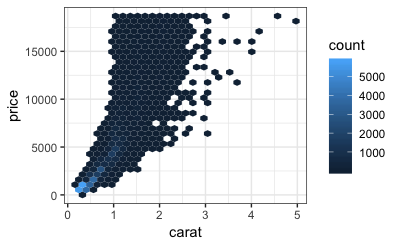

```r
# Bonus: geom_hex!
ggplot(diamonds, aes(x = carat, y = price)) +
  geom_hex()
```

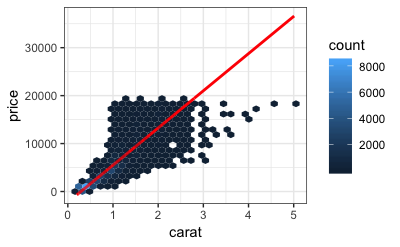

```r
caratmodel = lm(price ~ carat, data = diamonds)
grid = diamonds %>%
  add_predictions(model = caratmodel) %>%
  add_residuals(caratmodel)
ggplot(grid, aes(x = carat)) +
  geom_hex(aes(y = price)) +
  geom_line(aes(y = pred), colour = "red", size = 1)
```

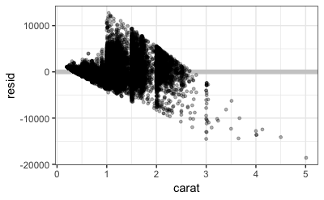

```r
grid %>%
  ggplot(aes(x = carat)) +
  geom_ref_line(h = 0, colour = "grey80") +
  geom_point(aes(y = resid), size = 1, alpha = .3)
```

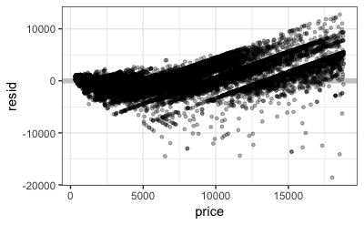

```r
grid %>%
  ggplot(aes(x = price)) +
  geom_ref_line(h = 0, colour = "grey80") +
  geom_point(aes(y = resid), size = 1, alpha = .3)
```

```r
# autoplot(caratmodel)
```

Solução: Transformar as variáveis para que elas passem a ter uma relação mais linear. É um processo de tentativa e erro a partir dos formatos observados. Por exemplo, se o formado de $y = f(x)$ é tal que y cresce exponencialmente com x (ou seja, $y = ae^{bx}$), e transformamos $y$ com log, temos que $ln(y) = ln(ae^{bx}) = ln(a) + bx$. Essa expressão modela uma relação linear entre $ln(y)$ e $x$.

Já se a relação $y = f(x)$ é no formato $y = ax^{b}$) podemos transformar $x$ e $y$ com log, temos que $ln(y) = ln(ax^{b}) = ln(a) + b log(x)$. Essa expressão modela uma relação linear entre $ln(y)$ e $ln(x)$.

A mesma lógica pode ser usada para logaritmos em outras bases e para raízes quadráticas ou outras transformadas. As transformações mais comuns a considerar são log(x), sqrt(x), exp(x) e $x^2$.

Aplicando para o caso dos diamantes:

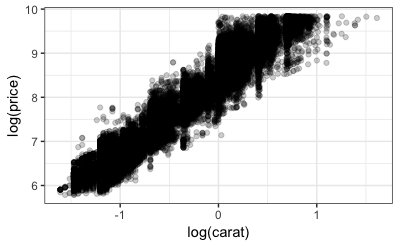

```r
ggplot(diamonds, aes(x = log(carat), y = log(price))) +
  geom_point(alpha = .2)
```

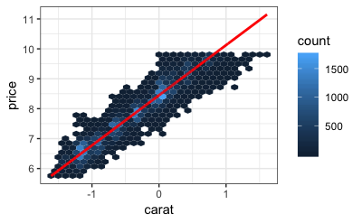

```r
diamonds2 = diamonds %>%
  transmute(carat = log(carat),
            price = log(price))
caratmodel = lm(price ~ carat, data = diamonds2)
grid = diamonds2 %>%
  add_predictions(model = caratmodel) %>%
  add_residuals(model = caratmodel)
ggplot(grid, aes(x = carat)) +
  geom_hex(aes(y = price)) +
  geom_line(aes(y = pred), colour = "red", size = 1)
```

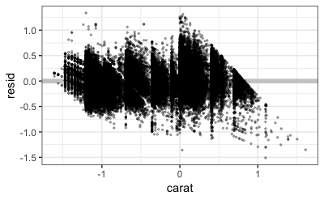

```r
grid %>%
  ggplot(aes(x = carat)) +
  geom_ref_line(h = 0, colour = "grey80") +
  geom_point(aes(y = resid), size = .5, alpha = .3)
```

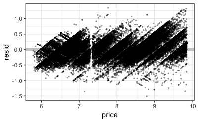

```r
grid %>%
  ggplot(aes(x = price)) +
  geom_ref_line(h = 0, colour = "grey80") +
  geom_point(aes(y = resid), size = .5, alpha = .3)
```

```r
# autoplot(caratmodel)
```

## Non-constant variance of error terms

Transformações ou weighted least squares.

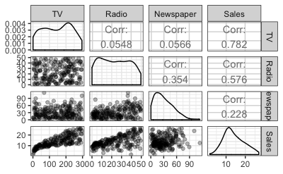

```r
advertising = read_csv("../dados/Advertising.csv") %>% rename(campaign = X1)
advertising %>%
  select(-campaign) %>%
  ggpairs(lower = list(continuous = wrap("points", alpha = 0.3)), progress = FALSE)
```

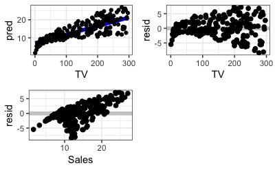

```r
tv.model = lm(Sales ~ TV, data = advertising)
adv_augmented = advertising %>%
  add_predictions(tv.model) %>%
  add_residuals(tv.model)
# Modelo x dados
p_md = adv_augmented %>%
  ggplot(aes(x = TV)) +
  geom_line(aes(y = pred), size = 2, colour = "blue") +
  geom_point(aes(y = Sales))
# Resíduos x preditor
p_rp = adv_augmented %>%
  ggplot(aes(x = TV)) +
  geom_ref_line(h = 0, colour = "grey80") +
  geom_point(aes(y = resid), size = 2)
# Resíduos x variável de resposta
p_rr = adv_augmented %>%
  ggplot(aes(x = Sales)) +
  geom_ref_line(h = 0, colour = "grey80") +
  geom_point(aes(y = resid), size = 2)
gridExtra::grid.arrange(p_md, p_rp, p_rr, ncol = 2)
```

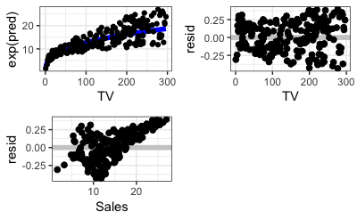

```r
tv.model2 = lm(log(Sales) ~ log(TV), data = advertising)
adv_augmented = advertising %>%
  add_predictions(tv.model2) %>%
  add_residuals(tv.model2)
# Modelo x dados
p_md = adv_augmented %>%
  ggplot(aes(x = TV)) +
  geom_line(aes(y = exp(pred)), size = 2, colour = "blue") +
  geom_point(aes(y = Sales))
# Resíduos x preditor
p_rp = adv_augmented %>%
  ggplot(aes(x = TV)) +
  geom_ref_line(h = 0, colour = "grey80") +
  geom_point(aes(y = resid), size = 2)
# Resíduos x variável de resposta
p_rr = adv_augmented %>%
  ggplot(aes(x = Sales)) +
  geom_ref_line(h = 0, colour = "grey80") +
  geom_point(aes(y = resid), size = 2)
gridExtra::grid.arrange(p_md, p_rp, p_rr, ncol = 2)
```

## Outliers e High-leverage points

Uma boa: http://setosa.io/ev/ordinary-least-squares-regression/

No plot de studentized residuals, pontos com resíduos normalizados maiores que 3 são suspeitos.

Para leverage, o adequado é olhar pontos com leverage muito acima dos demais, ou maior que (p + 1)/n. (p sendo o número de preditores.)

## Colinearity

Recomendação: VIF < 5 ou VIF < 10

```r
library(car)
mario <- read.csv("../dados/marioKart.txt", header = TRUE, sep = "\t")
mario <- filter(mario, totalPr < 100)
mlm <- lm(totalPr ~ startPr + cond, data = mario)
vif(mlm)
```

```
 startPr     cond
1.002439 1.002439
```

```r
multi = lm(Sales ~ TV + Newspaper + Radio, data = advertising)
vif(multi)
```

```
       TV Newspaper     Radio
 1.004611  1.145187  1.144952
```

```r
credit <- read_csv("../dados/Credit.csv") %>% select(-1)
names(credit)
```

```
 [1] "Income"    "Limit"     "Rating"    "Cards"     "Age"       "Education" "Gender"    "Student"
 [9] "Married"   "Ethnicity" "Balance"
```

```r
# credit.model = lm(Balance ~ Age + Student + Married, data = credit)
credit.model = lm(Balance ~ Age + Limit, data = credit)
tidy(credit.model, conf.int = TRUE)
```

| term | estimate | std.error | statistic | p.value | conf.low | conf.high |
| --- | --- | --- | --- | --- | --- | --- |
| (Intercept) | -173.410901 | 43.828387048 | -3.956589 | 9.005366e-05 | -259.5756445 | -87.2461583 |
| Age | -2.291486 | 0.672484540 | -3.407492 | 7.226468e-04 | -3.6135615 | -0.9694096 |
| Limit | 0.173365 | 0.005025662 | 34.495944 | 1.627198e-121 | 0.1634847 | 0.1832452 |

```r
glance(credit.model)
```

| r.squared | adj.r.squared | sigma | statistic | p.value | df | logLik | AIC | BIC | deviance | df.residual |
| --- | --- | --- | --- | --- | --- | --- | --- | --- | --- | --- |
| 0.7498386 | 0.7485784 | 230.5321 | 594.9878 | 3.521477e-120 | 3 | -2742.226 | 5492.452 | 5508.418 | 21098589 | 397 |

```r
credit.model2 = lm(Balance ~ Age + Rating + Limit, data = credit)
tidy(credit.model2, conf.int = TRUE)
```

| term | estimate | std.error | statistic | p.value | conf.low | conf.high |
| --- | --- | --- | --- | --- | --- | --- |
| (Intercept) | -259.51751854 | 55.88219241 | -4.6440110 | 4.656409e-06 | -369.3803781 | -149.6546590 |
| Age | -2.34575164 | 0.66861406 | -3.5083792 | 5.025853e-04 | -3.6602286 | -1.0312747 |
| Rating | 2.31045954 | 0.93952549 | 2.4591771 | 1.435238e-02 | 0.4633782 | 4.1575409 |
| Limit | 0.01901346 | 0.06296388 | 0.3019741 | 7.628303e-01 | -0.1047718 | 0.1427987 |

```r
vif(credit.model2)
```

```
       Age     Rating      Limit
  1.011385 160.668301 160.592880
```

```r
credit %>%
  select(Age, Rating, Limit) %>%
  cor()
```

```
             Age    Rating     Limit
Age    1.0000000 0.1031650 0.1008879
Rating 0.1031650 1.0000000 0.9968797
Limit  0.1008879 0.9968797 1.0000000
```